# Introduction to Python

*for scientific computing*

## Jupyter

- We'll use "**Jupyter Notebook**" to interact with Python.
- Like Matlab's 'Live Editor'; Maple's and Mathematica's notebooks.
- Runs in a *web browser*.

To get started:

# [`mas-jupyter.ncl.ac.uk`](https://mas-jupyter.ncl.ac.uk)

- Login with your usual university details
- Open `language.ipynb`

[figure not shown]

You can edit the code samples from the slides **live** and run them as you please.

- Double-click a cell to edit it.
- To run a cell's contents, use `Control-Enter`.
- You can also use `Shift-Enter` to run and move to the next cell.

```python
x = 1 + 1
10 * x
```

```
20
```

Today's course has two parts:

### Morning: the Python language

- Why, what, how?
- Basic data types and operations
- Control flow

### Afternoon: Python tools for scientists

- `NumPy`: working with large data grids
- `SciPy`: common numerical functions
- `matplotlib`: in-depth plotting library

Plus advice, links to resources, exercises, ...

# What is Python?

- Interpreted, object-oriented programming language
- Works on PC, Mac and Linux
- Open source: free (speech, lunch)

## Why Python?

- Neat and friendly syntax

```python
print("Hello, world!")
```

```
Hello, world!
```

- Newbie-friendly
- Quick to write code and quick (enough) to run
- 'Batteries included': e.g. JSON data handling

```python
import json, random
#Data obtained from http://www.imdb.com/interfaces
with open("data/top_250_imdb.json") as data_file:
    films = json.load(data_file)
```

```python
random.sample(films.items(), 3)
```

```
[('Yôjinbô (1961)', 8.2),
 ('Batman Begins (2005)', 8.2),
 ('Das Leben der Anderen (2006)', 8.4)]
```

```python
from statistics import mean
#This mean is just from the top 250!
mean(films.values())
```

```
8.2636
```

```python
max(films.values())
```

```
9.2
```

```python
print([name for name, score in films.items() if score == 9.2])
```

```
['The Shawshank Redemption (1994)', 'The Godfather (1972)']
```

More pros and cons discussed at the [SciPy tutorial](http://www.scipy-lectures.org/intro/intro.html#why-python).

## What can Python do?

- Work with large datasets (`Pandas` dataframes and `NumPy` arrays)

```python
import pandas #Data from Thomas Bland
df = pandas.read_csv("data/soliton_collision.csv", index_col=0)
df.shape
```

```
(450, 1021)
```

```python
df.head()
```

|  | 0 | 0.98 | 1.96 | 2.94 | 3.92 | 4.9 | 5.88 | 6.86 | 7.84 | 8.82 | ... | 990.78 | 991.76 | 992.74 | 993.72 | 994.7 | 995.68 | 996.66 | 997.64 | 998.62 | 999.6 |
| --- | --- | --- | --- | --- | --- | --- | --- | --- | --- | --- | --- | --- | --- | --- | --- | --- | --- | --- | --- | --- | --- |
| -22.5 | 1.0 | 0.99992 | 0.99991 | 0.99998 | 0.99944 | 0.99935 | 0.99995 | 0.99853 | 1.00030 | 1.0019 | ... | 0.99888 | 1.00010 | 0.99949 | 0.99871 | 0.99616 | 0.99866 | 0.99587 | 0.99769 | 0.99823 | 1.0014 |
| -22.4 | 1.0 | 0.99994 | 0.99992 | 1.00010 | 0.99947 | 0.99951 | 1.00000 | 0.99873 | 1.00030 | 1.0018 | ... | 0.99885 | 1.00000 | 0.99935 | 0.99860 | 0.99643 | 0.99857 | 0.99613 | 0.99769 | 0.99813 | 1.0015 |
| -22.3 | 1.0 | 0.99995 | 0.99993 | 0.99976 | 1.00000 | 0.99972 | 0.99986 | 0.99892 | 0.99978 | 1.0019 | ... | 0.99873 | 0.99983 | 0.99903 | 0.99840 | 0.99670 | 0.99842 | 0.99643 | 0.99770 | 0.99792 | 1.0016 |
| -22.2 | 1.0 | 0.99996 | 0.99994 | 0.99969 | 1.00010 | 1.00010 | 1.00000 | 0.99941 | 0.99972 | 1.0015 | ... | 0.99851 | 0.99944 | 0.99880 | 0.99835 | 0.99725 | 0.99816 | 0.99681 | 0.99766 | 0.99771 | 1.0018 |
| -22.1 | 1.0 | 0.99997 | 0.99995 | 0.99995 | 1.00040 | 1.00030 | 0.99980 | 0.99974 | 0.99997 | 1.0010 | ... | 0.99824 | 0.99916 | 0.99843 | 0.99825 | 0.99759 | 0.99808 | 0.99702 | 0.99763 | 0.99771 | 1.0018 |

5 rows × 1021 columns

- Data processing and visualisation (`matplotlib` and `MayaVi`)

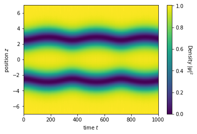

```python
subset = df[-7:7]

import matplotlib.pyplot as plt
plt.imshow(subset,                 #Like Matlab's pcolor()
           aspect='auto',
           extent=(0, 1000, -7, 7))

colorbar = plt.colorbar()
colorbar.ax.set_ylabel('Density $|\psi|^2$', labelpad=20, rotation=270)

plt.xlabel('time $t$')
plt.ylabel('position $z$')
plt.show()
```

- General purpose programming language (e.g. Python runs websites)
- Got a boring task to do? Automate it!

## How do I get Python?

Won't always have this notebook interface!

- At home: use the [Anaconda distribution](https://www.continuum.io/downloads) or [vanilla Python](https://www.python.org/)
- At uni: talk to your Computing officer.

### Python 2 or 3?

- Unless you're using someone else's code, **use Python 3**.
- Some blogs might tell you it's not supported by big packages but that's [not true any more](http://python3wos.appspot.com/).

Can try an IDE e.g. [Spyder](https://github.com/spyder-ide/spyder)

[figure not shown]

## Numeric types

### Integers: indexing or counting:

```python
1 + 2
```

```
3
```

```python
300 - 456
```

```
-156
```

### Floats: measuring continuous things.

```python
0.1 + 0.2    #limited precision
```

```
0.30000000000000004
```

```python
0.5 - 0.3
```

```
0.2
```

### Different data types for different jobs

### Python's numbers are friendly

```python
-2 ** 1000            # No problems with sign or under/overflow
```

```
-107150860718626732094842504906000181056140481170553360744375…
```

```python
type(-2 ** 1000)
```

```
int
```

```python
1 + 1.5              # Mix int and float: result is float
```

```
2.5
```

```python
type(12 + 24.0)      #Can check types explicitly
```

```
float
```

### Golden rule: if one part of an expression is a float, the entire expression will be a float

#### Other operations

```python
23 - 7.0
```

```
16.0
```

```python
2 * 4
```

```
8
```

```python
3 / 2               # division always returns a float in Python 3
```

```
1.5
```

```python
3 // 2              # double-slashes force integer division
```

```
1
```

```python
2 ** 3.0
```

```
8.0
```

```python
2 ^ 6               #Bitwise or -- not very useful for scientists
```

```
4
```

#### Even more operations

```python
(1 + 2) * (3 + 4)   #Brackets work as normal
```

```
21
```

```python
3 - 2*4             #Order of operations (BODMAS) as normal
```

```
-5
```

```python
27 % 5              #Modulo (remainder) operation
```

```
2
```

```python
abs(-2)             #Modulus (absolute value) function
```

```
2
```

### Advice for working with floats

- Floats accumlate rounding errors
- Testing equality is tricky (should use [`math.isclose`](https://docs.python.org/3/library/math.html#math.isclose))

```python
x = 0.1 + 0.2
y = 0.15 + 0.15
print("%.20f\n%.20f" % (x, y))
from math import isclose
isclose(x, y)
```

```
0.30000000000000004441
0.29999999999999998890
```

```
True
```

- See [Floating point guide](http://floating-point-gui.de/errors/comparison/) or [What every computer scientist should know about floating-point arithmetic](https://doi.org/10.1145/103162.103163)

### `complex` type

- Python uses `j` for the imaginary unit $i$.
- Has to have a number before it, to distinguish from a variable called `j`.

```python
1j * 1j
```

```
(-1+0j)
```

```python
z = 2 - 4j
z + z.conjugate()  # Twice the real part
```

```
(4+0j)
```

- use `cmath` functions when working with complex numbers.

```python
import cmath
cmath.sin(0.1 + 2j)
```

```
(0.37559284993485376+3.6087412126897433j)
```

```python
abs(cmath.exp(2j))
```

```
1.0
```

## Exercises

What are the types and values of the following expressions? Try to work it out by hand; then check in the notebook.

- `23 + 2 * 17 - 9`
- `23 + 2 * (17 - 9.0)`
- `5 * 6 / 7`
- `5 * 6 // 7`
- `5 * 6.0 // 7`
- `2.0 ** (3 + 7 % 3) // 2`
- `2 ** (3 + 7 % 3) / 2`
- `4 ** 0.5`
- `-4 ** 0.5`
- `(1 + 1/1000) ** 1000`
- int: `48`
- float: `39.0`
- float: `30/7 == 4.28571...6`
- int: `30 // 7 == 4`
- float: `30.0 // 7 == 4.0`
- float: `8.0`
- float: `8.0`
- float: `2.0`
- float: `-2.0`
- float: `2.71692...` $\approx e$

## Control flow: variables

Variables are names which refer to values.

```python
x = 10
2 * x + 4
```

```
24
```

```python
#Prefer descriptive names over shorthand
import math
planck = 6.63e-36
red_planck = planck / (2 * math.pi)
red_planck
```

```
1.0551972726992662e-36
```

```python
name = 'Dr. John Smith' #not just numbers: more data types later
len(name)
```

```
14
```

```python
thing1 = 3.142   #numbers okay in variable names
thing2 = 1.618
```

```python
3rdthing = 2.718 #except at the start
```

```
  File "<ipython-input-38-e4d50dee3627>", line 1
    3rdthing = 2.718 #except at the start
           ^
SyntaxError: invalid syntax
```

Some [keywords are forbidden](https://docs.python.org/3.6/reference/lexical_analysis.html#keywords).

```python
del = 'boy'
```

```
  File "<ipython-input-41-6e337587edb8>", line 1
    del = 'boy'
        ^
SyntaxError: invalid syntax
```

To *compare* variables and/or values, use two equals signs `==`. More on this later.

```python
t = 2
```

```python
t + t = 4
```

```
  File "<ipython-input-40-c6ff51bde1a1>", line 1
    t + t = 4
             ^
SyntaxError: can't assign to operator
```

```python
t + t == 4
```

```
True
```

### Quick quiz: what happens here?

```python
x = 1
y = x
x = x * 5
```

What's $y$ equal to: $1$ or $5$?

```python
y
```

```
1
```

When we say `y = x`, we mean

- Make `y` refer to whatever `x` refers to

and not

- Make `y` refer to `x`

If in doubt: try experimenting!

### Control flow: functions

- Packages and the standard library have many useful functions
- Still useful to write your own: reuse code, break program into smaller problems

```python
def discriminant(a, b, c):
    print("a =", a, "b =", b, "c =", c)
    return b ** 2 - 4 * a * c
```

- `def` keyword (define)
- function name (same rules as variables)
- argument list
- **colon** to mark indentation
- statements: **indented with four spaces**
- `return` expression

```python
discriminant(2, 3, 4)       #Give arguments values by position...
```

```
a = 2 b = 3 c = 4
```

```
-23
```

```python
discriminant(b=3, c=4, a=2) #...or explicitly by name
```

```
a = 2 b = 3 c = 4
```

```
-23
```

Python will complain if you don't give a function the right arguments.

```python
discriminant()
```

```
---------------------------------------------------------------------------
TypeError                                 Traceback (most recent call last)
<ipython-input-48-dc883d99b76f> in <module>()
----> 1 discriminant()

TypeError: discriminant() missing 3 required positional arguments: 'a', 'b', and 'c'
```

```python
discriminant(0, 0)
```

```
---------------------------------------------------------------------------
TypeError                                 Traceback (most recent call last)
<ipython-input-49-05674ee3aefb> in <module>()
----> 1 discriminant(0, 0)

TypeError: discriminant() missing 1 required positional argument: 'c'
```

```python
discriminant(a=1, a=2, a=3)
```

```
  File "<ipython-input-50-cf03c5c67bda>", line 1
    discriminant(a=1, a=2, a=3)
                     ^
SyntaxError: keyword argument repeated
```

Arguments can be made *optional* by giving them default values.

```python
def greet(greeting='Hello', name='stranger'):
    print(greeting, 'to you,', name)
```

```python
greet()
```

```
Hello to you, stranger
```

```python
greet('David')
```

```
David to you, stranger
```

```python
greet(name='David')
```

```
Hello to you, David
```

Can return more than one value at once:

```python
def consecutive_squares(n):
    return n**2, (n + 1)**2
```

```python
consecutive_squares(5)
```

```
(25, 36)
```

The function returns a `tuple` (more on these later). Can *unpack* to get at the individual values

```python
a, b = consecutive_squares(10)
a
```

```
100
```

```python
b
```

```
121
```

#### Variable scope: context matters

```python
a = 3
def double(a):
    a = 2 * a
    return a
```

```python
double(6)
```

```
12
```

Function arguments and variables defined in a function are *local* to the function body.

If there's a name conflict, stuff outside is unaffected.

```python
a
```

```
3
```

[See the Python tutorial](https://docs.python.org/3/tutorial/controlflow.html#more-on-defining-functions) for more tips, tricks and examples---including functions that take a *variable number of arguments*.

### Cheeky challenge

Write a function implements the quadratic formula.

- Arguments: three numbers $a$, $b$, and $c$
- Return **both** solutions to $ax^2 + bx + c = 0$
- Return the smaller one first

Reminder: the quadratic formula is $$x = \frac {-b \pm \sqrt{b^2 - 4ac}} {2a}$$

- Use `math.sqrt` for computing square roots. Don't forget to `import`!

Let's do a few tests.

- $(x-4)(x+2) = x^2 + 2x - 8$ has roots $x=4, x=-2$.
- $2(x-10)^2 = 2x^2 -40x + 400$ has a repeated root $x=10$.

```
print( quadratic_roots(1, 2, -8) )
#assert statements will error if the condition is False.
assert quadratic_roots(1, 2, -8) == (-2, 4)
assert quadratic_roots(2, -40, 400) == (10, 10)
```

### Control flow: loops

Basic looping has two important parts:

- `for variable in ...:`
- `range` function

```python
for i in range(5):
    print("Hello!")
```

```
Hello!
Hello!
Hello!
Hello!
Hello!
```

- loop body indented with four spaces (like functions)
- **colon** to denote indentation

#### Python's indexing convention

Something of length $N$ uses indices from $0$ to $N-1$ inclusive.

```python
for i in range(5):
    print("Here's a number:")
    print(i)
```

```
Here's a number:
0
Here's a number:
1
Here's a number:
2
Here's a number:
3
Here's a number:
4
```

- unlike Matlab, Fortran or R (where indexing starts from 1).
- like C, C++, Java, Javascript
- [EWD831](https://www.cs.utexas.edu/users/EWD/ewd08xx/EWD831.PDF) discusses different indexing systems
- [Wikipedia](https://en.wikipedia.org/wiki/Comparison_of_programming_languages_%28array%29#Array_system_cross-reference_list) compares across languages.

#### Controlling integer ranges

The most general form of the [`range`](https://docs.python.org/3/library/stdtypes.html#range) function is

`range(start, stop, step)`

Where `step` has default value of `1` when it's missing.

```python
for i in range(5, 10):
    print(i)
```

```
5
6
7
8
9
```

```python
for i in range(10, 20, 2):
    print(i)
```

```
10
12
14
16
18
```

Python assumes that start ≤ stop.

```python
for thing in range(50, 40): #can use any loop variable
    print(thing)
```

If you want a descending loop you need a negative step.

```python
for thing in range(50, 40, -3):
    print(thing)
```

```
50
47
44
41
```

### Cheeky challenge

Use a loop to compute $$5^2 + 10^2 + 15^2 + 20^2 + \dotsb + 200^2$$

```
#Again here's a template for you
total = 0
for ... in ...:
    total = total + ...
total
```

```
#Here's the answer you should have got:
assert total == 553500
```

We'll see later that we can loop over all sorts of objects---not just `range`s.

```python
for character in "David Matthew Robertson":
    print(character, end=".")
```

```
D.a.v.i.d. .M.a.t.t.h.e.w. .R.o.b.e.r.t.s.o.n.
```

This makes looping a really powerful tool in Python. It enables

- Shortcuts like the [`enumerate` function](https://docs.python.org/3.6/library/functions.html#enumerate)
- [Generator expressions and generator functions](http://www.dabeaz.com/generators/)
- [List](https://docs.python.org/3.6/tutorial/datastructures.html#list-comprehensions)/Set/Dictionary comprehensions
- [Efficient looping](https://docs.python.org/3/library/itertools.html) techniques

Just like other languages, there are [`while` loops](https://docs.python.org/3/reference/compound_stmts.html#the-while-statement) and [`break` and `continue` statements](https://docs.python.org/3.4/tutorial/controlflow.html#break-and-continue-statements-and-else-clauses-on-loops) which are a bit less intuitive.

There's too much to go over here---but there are links in the notebook if you're curious.

### Control flow: conditionals

A very important tool in the programmer's toolkit is the ability to do different things in different circumstances.

Enter the **`if` statement**:

```python
i = 10
if i % 2 == 0:
    print(i, "is even")
```

```
10 is even
```

- *Colon*, then four spaces before body statements
- Main expression usually a boolean: `True` or `False`
- Use comparisons like `<`, `<=`, `==`, `!=`, `>=`, `>` to make booleans

```python
1 < 2    #less than
```

```
True
```

```python
2 <= 0.2   #less than or equal
```

```
False
```

```python
3 == 3.0   #equal
```

```
True
```

```python
"cat" != "dog" #not equal
```

```
True
```

```python
x = 10
1 < x < 15 #Mathematical notation for "(1 < x) and (x < 15)"
```

```
True
```

Let's take our previous if statement and put it in a loop.

Whenever we start a **new block** (line ending in a colon), we have to indent an extra four spaces.

```python
for i in range(5):
    if i % 2 == 0:
        print(i, "is even")
```

```
0 is even
2 is even
4 is even
```

We can handle the `False` case with an `else` statement.

```python
for i in range(5):
    if i % 2 == 0:
        print(i, "is even")
    else:
        print(i, "is odd")
```

```
0 is even
1 is odd
2 is even
3 is odd
4 is even
```

For finer control, use an `if... elif... else...` chain.

Here **`elif`** is short for "else if".

```python
import datetime
now = datetime.datetime.now()
print("The time is", now, "and the hour is:", now.hour)
if 6 <= now.hour < 12:
    print("Good morning!")
elif now.hour < 18:
    print("Good afternoon!")
elif now.hour < 20:
    print("Good evening!")
else:
    print("Good night!")
```

```
The time is 2017-04-11 12:48:23.167619 and the hour is: 12
Good afternoon!
```

- `else` is optional and always comes last.
- Need to have `if` before any `elif`s.
- Can have as many `elif`s as you like.

### Cheeky challenge

The *sign* or *signum* function is defined by $$\operatorname{sign}(x) = \begin{cases} \phantom{-}1 & \text{if $x>0$} \\ \phantom{-}0 & \text{if $x=0$} \\ -1 & \text{if $x<0$} \end{cases}$$

Implement this as a Python function.

```
#And some tests:
assert sign(10) == 1
assert sign(0) == 0
assert sign(-23.4) == -1
```

- Quick mention: can perform logical operations on booleans with **`and`**, **`or`**, and **`not`**.

```python
True and False
```

```
False
```

```python
True or False
```

```
True
```

```python
not False
```

```
True
```

```python
not False and False    #careful with order of operations
```

```
False
```

```python
not (False and False)
```

```
True
```

## Data types: strings

- Any textual data: plot labels, file names, ...
- Enclosed by single (`'`) or double quotes (`"`)
- Any Unicode character okay

```python
supercal = "Supercalifragilisticexpialidocious"
starwars = 'No, I am your father'  # spaces okay
greeting = "こんにちは (Konnichiwa)" # non-Latin characters okay
```

- Use `\n` to stand for a newline
- Use `\'` or `\"` for literal quotes
- Use `\\` for a literal backslash
- Spaces preserved

```python
print("A short 'quote'\n     a double quote char: \"\n and newlines!")
```

```
A short 'quote'
     a double quote char: "
 and newlines!
```

### Python is pedantic when comparing

```python
'2' == 2            #different types!
```

```
False
```

```python
type('2'), type(2)
```

```
(str, int)
```

```python
'True' == True
```

```
False
```

```python
type('True'), type(True)
```

```
(str, bool)
```

### String methods

A list of handy funtions for working with strings. [Full reference](https://docs.python.org/3/library/stdtypes.html#string-methods) online.

```python
vowels = "aeiou"
vowels.upper()
```

```
'AEIOU'
```

```python
vowels.lower() #already lowercase
```

```
'aeiou'
```

```python
vowels.capitalize()
```

```
'Aeiou'
```

```python
len(supercal)   #length function
```

```
34
```

```python
supercal.count("a")
```

```
3
```

Silly example: a function which processes a yes/no prompt (y/n)

```python
def handle_response(response):
    if response.startswith("y"):
        return "positive response"
    elif response.startswith("n"):
        return "negative response"
    else:
        return "unclear response"
```

```python
handle_response("yes")
```

```
'positive response'
```

```python
handle_response("no way man that's unreasonable")
```

```
'negative response'
```

What happens when we call with these arguments? Guess, then check in the notebook.

- `handle_response()`
- `handle_response("")`
- `handle_response("YES")`
- `handle_response(" yes ")`

`handle_response()`

- `TypeError`: missing argument

`handle_response("")`

- Unclear response: the empty string `""` doesn't start with anything!

`handle_response("YES")`

- Unclear response: upper/lowercase matters for comparison

```python
'Y' == 'y'
```

```
False
```

`handle_response(" yes ")`

- Unclear response: first char is a space

Often useful to **normalise** strings to a sensible form, especially if they come from user input.

```python
response = "    YeS   "
response = response.lower()
print( repr(response) )      # explicitly representation with repr()
response = response.strip()  # remove whitespace from start and end
print( repr(response) )
```

```
'    yes   '
'yes'
```

Also handy: [`str.replace`](https://docs.python.org/3/library/stdtypes.html#str.replace):

```python
x = "The news media reported today that no news is in fact good news"
x.replace("news", "FAKE NEWS!!")
```

```
'The FAKE NEWS!! media reported today that no FAKE NEWS!! is in fact good FAKE NEWS!!'
```

### Slicing

Remember that indexing works from $0$ to $N - 1$:

```python
supercal[0]
```

```
'S'
```

```python
supercal[5]
```

```
'c'
```

```python
supercal[0:5] #like range, slicing excludes upper limit
```

```
'Super'
```

```python
supercal[-1]  #Last char
```

```
's'
```

```python
supercal[:5] + "..." + supercal[-4:] #first five, then last 4
```

```
'Super...ious'
```

### Concatenation

- Glue strings together with "+".
- For complicated gluings, or gluings of arbitrary length, use the [`print`](https://docs.python.org/3/library/functions.html#print) function or [`str.join`](https://docs.python.org/3/library/stdtypes.html#str.join)

```python
name = "David"
"Good morning, " + name + "."
```

```
'Good morning, David.'
```

- Use `*` as shorthand for repitition.

```python
'thank you ' * 10
```

```
'thank you thank you thank you thank you thank you thank you thank you thank you thank you thank you '
```

Even more complicated string handling available:

- Printf-style formatting and the format() function
- [Python 3.6's f-strings](https://docs.python.org/3/reference/lexical_analysis.html#f-strings).

### Looping over strings

Awkward way:

```python
example = "demo"
for i in range(len(example)):
    print(example[i])
```

```
d
e
m
o
```

Slick way:

```python
for character in "demo":
    print(character)
```

```
d
e
m
o
```

### Cheeky Challenge

Write a function to count the number of vowels in a string. Assume that we're just working with the Roman alphabet---so don't worry about variants like ë, è, é, and ê.

For bonus points, try using a loop to write this function.

```python
#Here's a space to write your function
```

```
#and some tests to run
assert your_function("Hello") == 2
assert your_function(" xyz HEllO") == 2
assert your_function("Hello, sailor") == 5
```

## Data types: lists and tuples

- Lists: a sequence of arbitrary Python objects

```python
greek_letters = ["alpha", "beta", "gamma", "delta"]
greek_letters[1] #Index just like strings: 0 to N-1.
```

```
'beta'
```

- Lists can be modified in-place

```python
greek_letters[1] = "BETA (β)"
greek_letters
```

```
['alpha', 'BETA (β)', 'gamma', 'delta']
```

- Lists can contain objects of different types

```python
things = ["uno", "dos", 3, supercal, 2.718]
```

- Unless they're modified, lists have a fixed length

```python
len(things)
```

```
5
```

- Lists are objects, so lists can even contain lists!

```python
names_by_parts = [ ["David", "Robertson"], ["Cetin", "Can", "Evirgen"] ]
print( names_by_parts[0] )
print( names_by_parts[0][1] )
```

```
['David', 'Robertson']
Robertson
```

### Quick Quiz

What is `len(names_by_parts)`?

- 2
- 3
- 4
- 5

```python
len(names_by_parts)
```

```
2
```

- A list doesn't know anything special about what it contains
- Can't access or add new list items by accident

```python
greek_letters[4]
```

```
---------------------------------------------------------------------------
IndexError                                Traceback (most recent call last)
<ipython-input-117-85a9bd08274d> in <module>()
----> 1 greek_letters[4]

IndexError: list index out of range
```

```python
greek_letters[4] = 'EPSILON (ε)'
```

```
---------------------------------------------------------------------------
IndexError                                Traceback (most recent call last)
<ipython-input-118-233d7087fd08> in <module>()
----> 1 greek_letters[4] = 'EPSILON (ε)'

IndexError: list assignment index out of range
```

- Use [list methods](https://docs.python.org/3/tutorial/datastructures.html) to modify the list itself, rather than its contents.
- See also [full list description](https://docs.python.org/3/library/stdtypes.html#list)

```python
greek_letters.append("EPSILON (ε)")
greek_letters
```

```
['alpha', 'BETA (β)', 'gamma', 'delta', 'EPSILON (ε)']
```

- Other useful list methods and idoms:

```python
empty_list = []
print(empty_list, len(empty_list))
```

```
[] 0
```

```python
numbers = [5, 2, 64, 41, 27, -2, 11, 32]
```

```python
numbers.sort()     #modifies list in place
numbers
```

```
[-2, 2, 5, 11, 27, 32, 41, 64]
```

```python
["ab", 1].sort()  # Can't compare text with numbers
```

```
---------------------------------------------------------------------------
TypeError                                 Traceback (most recent call last)
<ipython-input-123-c281d25ec96a> in <module>()
----> 1 ["ab", 1].sort()  # Can't compare text with numbers

TypeError: '<' not supported between instances of 'int' and 'str'
```

```python
x = list(range(10, 20))
x
```

```
[10, 11, 12, 13, 14, 15, 16, 17, 18, 19]
```

```python
del x[2]  #Delete the entry with index 2 (third entry)
x
```

```
[10, 11, 13, 14, 15, 16, 17, 18, 19]
```

```python
print("POP:", x.pop(), x)
```

```
POP: 19 [10, 11, 13, 14, 15, 16, 17, 18]
```

```python
x.reverse() #modifies in place
x
```

```
[18, 17, 16, 15, 14, 13, 11, 10]
```

```python
x.insert(4, "surprise")
x
```

```
[18, 17, 16, 15, 'surprise', 14, 13, 11, 10]
```

**NB:** It's quick to extend lists at the end, but inserting or delete near the start is slower. If your list is HUGE then this can become a problem.

See also the [Python wiki](https://wiki.python.org/moin/TimeComplexity) or these [course notes](https://www.ics.uci.edu/~pattis/ICS-33/lectures/complexitypython.txt).

Looping over lists is just like strings.

**Warning**: [don't modify list structure](http://stackoverflow.com/a/10812734/5252017) when looping! (Modifying list values is fine)

```python
colours = ["red", "orange", "yellow", "green", "blue", "indigo", "violet"]
for colour in colours:
    print(colour, "has", len(colour), "letters" )
```

```
red has 3 letters
orange has 6 letters
yellow has 6 letters
green has 5 letters
blue has 4 letters
indigo has 6 letters
violet has 6 letters
```

```python
for colour in colours:
    colours.pop()
colours
```

```
['red', 'orange', 'yellow']
```

```python
for i, colour in enumerate(colours): #avoids range(len(colours))
    colours[i] = colour.upper()
colours
```

```
['RED', 'ORANGE', 'YELLOW']
```

### Cheeky challenge

The following lines will read a list of words from a data file. Use Python to find:

- The first, middle and last word in the list
- The percentage of words containing an `e`
  - Hint: use `str.find`; or better the `in` operator
- All two-letter words in the list (good for Scrabble)

```python
with open('data/en-GB-words.txt', 'rt') as f:
    words = [line.strip() for line in f]
print(len(words), "words. Number 2001 is", words[2000])
```

```
99156 words. Number 2001 is Booth
```

```python
N = len(words)
print(words[0], words[N//2], words[-1], sep=", ")
```

```
A, harks, études
```

```python
count = 0
for word in words:
    if 'e' in word:
        count = count + 1
print(count, 100 * count / len(words))
```

```
63152 63.689539715196254
```

```python
two_letter_words = []
for word in words:
    if len(word) == 2:
        two_letter_words.append(word)
print(two_letter_words)
```

```
['Ac', 'Ag', 'Al', 'Am', 'Ar', 'As', 'At', 'Au', 'Av', 'Ba', 'Be', 'Bi', 'Bk', 'Br', 'Ca', 'Cd', 'Cf', 'Ci', 'Cl', 'Cm', 'Co', 'Cr', 'Cs', 'Cu', 'Di', 'Dr', 'Ed', 'Er', 'Es', 'Eu', 'Fe', 'Fm', 'Fr', 'GE', 'Ga', 'Gd', 'Ge', 'He', 'Hf', 'Hg', 'Ho', 'Hz', 'In', 'Io', 'Ir', 'It', 'Jo', 'Jr', 'Kr', 'La',…
```

### Tuples

- The same as a list, except **can't be modified after creation**.
- Created with round brackets, not square
- Still indexed from $0$ to $N-1$

```python
coordinate = (1, 2, 3)
coordinate
```

```
(1, 2, 3)
```

```python
coordinate[0]
```

```
1
```

```python
coordinate[0] = 10
```

```
---------------------------------------------------------------------------
TypeError                                 Traceback (most recent call last)
<ipython-input-138-9acc16226b5e> in <module>()
----> 1 coordinate[0] = 10

TypeError: 'tuple' object does not support item assignment
```

```python
x, y, z = coordinate      #tuple unpacking
print(x, y, z, x + y + z)
```

```
1 2 3 6
```

In fact, when you say `return a, b` from a function, what gets returned is the tuple `(a, b)`!

## Data types: dictionaries

- Unordered collection of pairs `key -> value`
- Keys usually strings
- "Hashmap", "Associative array"

```python
david = dict(
    surname = "Robertson",
    given_names = ["David", "Matthew"],
    age = 24,
    dob = "26/06/1992",
    height = 190
)
david
```

```
{'age': 24,
 'dob': '26/06/1992',
 'given_names': ['David', 'Matthew'],
 'height': 190,
 'surname': 'Robertson'}
```

- Index by key to get/set values

```python
david['age'] = "very very very very very very old"
david['age']
```

```
'very very very very very very old'
```

### Three ways to loop:

```python
for key in david:
    print(key, end=", ")
```

```
surname, given_names, age, dob, height,
```

```python
for value in david.values():
    print(value, end=", ")
```

```
Robertson, ['David', 'Matthew'], very very very very very very old, 26/06/1992, 190,
```

```python
for key, value in david.items():
    print(key, "->", value)
```

```
surname -> Robertson
given_names -> ['David', 'Matthew']
age -> very very very very very very old
dob -> 26/06/1992
height -> 190
```

- Dictionaries have a length too:

```python
len(david)
```

```
5
```

- Python will complain if you ask for a missing key:

```python
david['weight']
```

```
---------------------------------------------------------------------------
KeyError                                  Traceback (most recent call last)
<ipython-input-146-01a69e534c10> in <module>()
----> 1 david['weight']

KeyError: 'weight'
```

- Can check if a key is present with `in`:

```python
'surname' in david
```

```
True
```

- NB: The Python community [tends to prefer](http://softwareengineering.stackexchange.com/a/225244) [`dict.get()`](https://docs.python.org/3/library/stdtypes.html#dict.get) or exception handling when keys might be missing.

### Cheeky challenge

The [following data file](https://github.com/Bowserinator/Periodic-Table-JSON) contains the periodic table as a dictionary. We're going to load it into a list, and each entry of that list will be a dictionary.

```python
import os
import json
with open("data/PeriodicTable.json", "rt") as f:
    table = json.loads(f.read())['elements']
```

```python
table[0]
```

```
{'appearance': 'colorless gas',
 'atomic_mass': 1.008,
 'boil': 20.271,
 'category': 'diatomic nonmetal',
 'color': None,
 'density': 0.08988,
 'discovered_by': 'Henry Cavendish',
 'melt': 13.99,
 'molar_heat': 28.836,
 'name': 'Hydrogen',
 'named_by': 'Antoine Lavoisier',
 'number': 1,
 'period': 1,
 'phase': 'Gas',
 'shells': [1],
 'source': 'https://en.wikipedia.org/wiki/Hydrogen',
 'spectral_img': 'https://en.wikipedia.org/wiki/File:Hydrogen_Spectra.jpg',
 'summary': 'Hydrogen is a chemical element with chemical symbol H and atomic number 1. With an atomic weight of 1.00794 u, hydrogen is the lightest element on the periodic table. Its monatomic form (H) is the most abundant chemical substance in the Universe, constituting roughly 75% of all baryonic…
 'symbol': 'H',
 'xpos': 1,
 'ypos': 1}
```

Your challenges:

- Which element is densest?
- Create a new dictionary mapping elements' symbols to their names. For example, if `D` is the dictionary, `D['H'] == 'Hydrogen'`.
- Sorted alphabetically, what's the first and last element symbol?
- Sorted alphabetically, what's the first and last element *name*?
- How many elements' symbols have a different first letter to their name?

```python
max_density = 0
max_density_name = ""
for element in table:
    if element['density'] != None and element['density'] > max_density:
        max_density = element['density']
        max_density_name = element['name']
max_density, max_density_name
```

```
(40.7, 'Hassium')
```

```python
shorthand = {}
for element in table:
    symbol = element['symbol']
    name = element['name']
    shorthand[symbol] = name
shorthand
```

```
{'Ac': 'Actinium',
 'Ag': 'Silver',
 'Al': 'Aluminium',
 'Am': 'Americium',
 'Ar': 'Argon',
 'As': 'Arsenic',
 'At': 'Astatine',
 'Au': 'Gold',
 'B': 'Boron',
 'Ba': 'Barium',
 'Be': 'Beryllium',
 'Bh': 'Bohrium',
 'Bi': 'Bismuth',
 'Bk': 'Berkelium',
 'Br': 'Bromine',
 'C': 'Carbon',
 'Ca': 'Calcium',
 'Cd': 'Cadmium',
 'Ce': 'Cerium',
 'Cf': 'Californium',
 'Cl': 'Chlorine',
 'Cm': 'Curium',
 'Cn': 'Copernicium',
 'Co': 'Cobalt',
 'Cr': 'Chromium',
 'Cs': 'Cesium',
 'Cu': 'Copper',
 'Db': 'Dubnium',
 'Ds': 'Darmstadtium',
 'Dy': 'Dysprosium',
 'Er': 'Erbium',
 'Es': 'Einsteinium',
 'Eu': 'Europium',
 'F': 'Fluorine',
 'Fe': 'Iron',
 'Fl': 'Flerovium',
 'Fm': 'Fermium',
 'Fr': 'Francium',
 'Ga': 'Gallium',
 'Gd': 'Gadolinium',
```

[output cut: 63 more lines]

```
 'Tc': 'Technetium',
 'Te': 'Tellurium',
 'Th': 'Thorium',
 'Ti': 'Titanium',
 'Tl': 'Thallium',
 'Tm': 'Thulium',
 'Ts': 'Tennessine',
 'U': 'Uranium',
 'V': 'Vanadium',
 'W': 'Tungsten',
 'Xe': 'Xenon',
 'Y': 'Yttrium',
 'Yb': 'Ytterbium',
 'Zn': 'Zinc',
 'Zr': 'Zirconium'}
```

```python
symbols = list(shorthand)
symbols.sort()
symbols[0], symbols[-1]
```

```
('Ac', 'Zr')
```

```python
names = list(shorthand.values())
names.sort()
names[0], names[-1]
```

```
('Actinium', 'Zirconium')
```

```python
oddballs = {}
for symbol, name in shorthand.items():
    if name[0] != symbol[0]:
        oddballs[symbol] = name
oddballs
```

```
{'Ag': 'Silver',
 'Au': 'Gold',
 'Fe': 'Iron',
 'Hg': 'Mercury (element)',
 'K': 'Potassium',
 'Na': 'Sodium',
 'Pb': 'Lead',
 'Sb': 'Antimony',
 'Sn': 'Tin',
 'W': 'Tungsten'}
```

## After lunch:

- Can will give a crash course in Python's scientific libraries
- Some more exercises, chances to practise

# That's all folks!

## Feedback, comments, questions?

### d.m.robertson@newcastle.ac.uk